# Cell2Cell | Random Forest

```r
library(randomForest)
library(tidyverse)
```

## Preprocessing

Use the generated_data and split manifest to get the training, validation, and test sets.

```r
source("R/preprocessing.R")

cleaned <- read.csv("Generated_Data/cleaned_data.csv", na.strings = c("", "NA"))
manifest <- read.csv("Generated_Data/split_manifest.csv")

stopifnot(
  !anyDuplicated(cleaned$CustomerID),
  !anyDuplicated(manifest$CustomerID),
  setequal(cleaned$CustomerID, manifest$CustomerID)
)

data <- cleaned[match(manifest$CustomerID, cleaned$CustomerID), ]
data$split <- manifest$split
data$cv_fold <- manifest$cv_fold
data <- add_cell2cell_features(data)

# Separate training and test data
training <- subset(data, split == "train")
test <- subset(data, split == "test")

stopifnot(
  !anyNA(training$cv_fold),
  setequal(unique(training$cv_fold), 1:3),
  all(is.na(test$cv_fold))
)

table(training$cv_fold)
```

```
##
##     1     2     3
## 12762 12762 12761
```

```r
table(training$Churn)
```

```
##
##    No   Yes
## 27252 11033
```

```r
# dimensions
dim(training)
```

```
## [1] 38285    65
```

```r
dim(test)
```

```
## [1] 12762    65
```

There are two recommended predictor sets for the random forest model.

```r
handoff_predictors <- cell2cell_handoff_predictors()
forest_terms <- handoff_predictors$forest

model_terms <- list(
  focused_raw = forest_terms$focused_raw,
  broader_raw = forest_terms$broader_raw
)

# All unique predictors used across the two models
inputs <- unique(unlist(model_terms, use.names = FALSE))

# Check that all predictors exist
stopifnot(
  all(inputs %in% names(training)),
  all(inputs %in% names(test))
)
```

Train the model using the three outreach capacities like in the logistic regression model.

```r
capacities <- c(0.10, 0.20, 0.30)

evaluate_forest <- function(actual, probability, customer_id, model_name, fold_id) {

  outcome <- as.numeric(as.character(actual))

  positives <- sum(outcome == 1)
  negatives <- sum(outcome == 0)

  stopifnot(
    !anyNA(outcome),
    positives > 0,
    negatives > 0
  )

  # Calculate AUC
  auc <- (
    sum(rank(probability)[outcome == 1]) -
      positives * (positives + 1) / 2
  ) / (positives * negatives)

  # Rank customers by predicted churn probability
  ranked <- order(-probability, customer_id)

  # Evaluate different outreach capacities
  precision <- vapply(capacities, function(capacity) {
    n_contact <- floor(capacity * length(ranked))
    contacted <- head(ranked, n_contact)
    mean(outcome[contacted] == 1)
  }, numeric(1))

  # Calculate lift
  lift <- precision / mean(outcome == 1)

  data.frame(
    Model = model_name,
    Fold = fold_id,
    Capacity = capacities,
    AUC = auc,
    Precision = precision,
    Lift = lift
  )
}
```

### Three-fold Cross Validation

This will train the model at each capacity for each fold. This may take a while to run.

```r
fold_results <- list()
fold_models <- list()

for (fold_id in 1:3) {

  cat("Validation fold:", fold_id, "\n")

  # Split analysis and assessment data
  analysis <- training[training$cv_fold != fold_id, ]
  assessment <- training[training$cv_fold == fold_id, ]

  # Preprocess using analysis data only
  processed <- prepare_cell2cell_fold(
    analysis,
    assessment,
    inputs
  )

  analysis <- processed$analysis
  assessment <- processed$assessment

  # Fit and evaluate both Random Forest models
  fold_results[[fold_id]] <- do.call(
    rbind,
    lapply(names(model_terms), function(candidate) {

      predictors <- model_terms[[candidate]]

      # Set churn outcome as a factor
      outcome <- factor(
        as.character(analysis$churn_flag),
        levels = c("0", "1")
      )

      # Fit Random Forest
      set.seed(123 + fold_id)

      fit <- randomForest(
        x = analysis[, predictors, drop = FALSE],
        y = outcome,
        ntree = 500,
        importance = TRUE
      )

      # Predict churn probabilities
      probability <- predict(
        fit,
        newdata = assessment[, predictors, drop = FALSE],
        type = "prob"
      )[, "1"]

      stopifnot(
        length(probability) == nrow(assessment),
        all(is.finite(probability))
      )

      # Evaluate model
      results <- evaluate_forest(
        actual = assessment$churn_flag,
        probability = probability,
        customer_id = assessment$CustomerID,
        model_name = candidate,
        fold_id = fold_id
      )

      # Save fitted model
      fold_models[[paste(candidate, fold_id, sep = "_")]] <<- fit

      results
    })
  )
}
```

```
## Validation fold: 1
## Validation fold: 2
## Validation fold: 3
```

```r
# Combine results from all folds
fold_scores <- do.call(rbind, fold_results)

row.names(fold_scores) <- NULL

fold_scores
```

```
##          Model Fold Capacity       AUC Precision     Lift
## 1  focused_raw    1      0.1 0.6291066 0.4568966 1.585349
## 2  focused_raw    1      0.2 0.6291066 0.4271160 1.482016
## 3  focused_raw    1      0.3 0.6291066 0.3968130 1.376870
## 4  broader_raw    1      0.1 0.6528722 0.5211599 1.808331
## 5  broader_raw    1      0.2 0.6528722 0.4474922 1.552718
## 6  broader_raw    1      0.3 0.6528722 0.4198015 1.456636
## 7  focused_raw    2      0.1 0.6377001 0.4490596 1.558156
## 8  focused_raw    2      0.2 0.6377001 0.4247649 1.473858
## 9  focused_raw    2      0.3 0.6377001 0.4025601 1.396811
## 10 broader_raw    2      0.1 0.6572629 0.5070533 1.759384
## 11 broader_raw    2      0.2 0.6572629 0.4572884 1.586709
## 12 broader_raw    2      0.3 0.6572629 0.4198015 1.456636
## 13 focused_raw    3      0.1 0.6373469 0.4639498 1.610134
## 14 focused_raw    3      0.2 0.6373469 0.4353448 1.510861
## 15 focused_raw    3      0.3 0.6373469 0.3991641 1.385296
## 16 broader_raw    3      0.1 0.6573930 0.5078370 1.762444
## 17 broader_raw    3      0.2 0.6573930 0.4635580 1.608774
## 18 broader_raw    3      0.3 0.6573930 0.4198015 1.456918
```

Summarize the model’s performance across the three cross validation folds.

```r
cv_summary <- aggregate(
  cbind(AUC, Precision, Lift) ~ Model + Capacity,
  data = fold_scores,
  FUN = mean
)

# Calculate standard deviation across folds
cv_sd <- aggregate(
  cbind(AUC, Precision, Lift) ~ Model + Capacity,
  data = fold_scores,
  FUN = sd
)

names(cv_sd)[names(cv_sd) == "AUC"] <- "AUC_SD"
names(cv_sd)[names(cv_sd) == "Precision"] <- "Precision_SD"
names(cv_sd)[names(cv_sd) == "Lift"] <- "Lift_SD"

# Combine mean and standard deviation
cv_summary <- merge(
  cv_summary,
  cv_sd,
  by = c("Model", "Capacity")
)

cv_summary <- cv_summary[
  order(
    cv_summary$Capacity,
    -cv_summary$Precision,
    -cv_summary$AUC,
    -cv_summary$Lift
  ),
]

row.names(cv_summary) <- NULL

print(cv_summary, row.names = FALSE)
```

```
##        Model Capacity       AUC Precision     Lift      AUC_SD Precision_SD
##  broader_raw      0.1 0.6558427 0.5120167 1.776720 0.002573382  0.007927895
##  focused_raw      0.1 0.6347179 0.4566353 1.584546 0.004862672  0.007448578
##  broader_raw      0.2 0.6558427 0.4561129 1.582734 0.002573382  0.008097170
##  focused_raw      0.2 0.6347179 0.4290752 1.488912 0.004862672  0.005555426
##  broader_raw      0.3 0.6558427 0.4198015 1.456730 0.002573382  0.000000000
##  focused_raw      0.3 0.6347179 0.3995124 1.386326 0.004862672  0.002889352
##       Lift_SD
##  0.0274190126
##  0.0259984118
##  0.0282390850
##  0.0194413688
##  0.0001628003
##  0.0100105567
```

This chooses the model with the highest Precision and AUC score from the previous summary. The selected model used the predictor set labelled `broader_raw`

```r
# Average precision across outreach capacities
model_precision <- aggregate(
  Precision ~ Model,
  data = cv_summary,
  FUN = mean
)

# Average AUC across outreach capacities
model_auc <- aggregate(
  AUC ~ Model,
  data = cv_summary,
  FUN = mean
)

model_comparison <- merge(
  model_precision,
  model_auc,
  by = "Model"
)

model_comparison <- model_comparison[
  order(
    -model_comparison$Precision,
    -model_comparison$AUC
  ),
]

print(model_comparison, row.names = FALSE)
```

```
##        Model Precision       AUC
##  broader_raw 0.4626437 0.6558427
##  focused_raw 0.4284076 0.6347179
```

```r
# Select the best model
selected_model <- model_comparison$Model[1]

cat("Selected model:", selected_model, "\n")
```

```
## Selected model: broader_raw
```

### Final Random Forest Model

This trains the final model using the chosen set of predictors on the entire training set.

```r
# Define saved model paths
model_path <- "models/final_forest.rds"
predictors_path <- "models/selected_predictors.rds"
processed_path <- "models/final_processed.rds"

# Check if all saved files exist
if (all(file.exists(
  model_path,
  predictors_path,
  processed_path
))) {

  cat("Saved model files found. Loading...\n")

  # Load saved files
  final_forest <- readRDS(model_path)
  selected_predictors <- readRDS(predictors_path)
  final_processed <- readRDS(processed_path)

  final_training <- final_processed$analysis
  final_test <- final_processed$assessment

  cat("Saved model loaded successfully.\n")

} else {

  cat("Saved model files not found. Training final model...\n")

  # Get predictors for the selected model
  selected_predictors <- model_terms[[selected_model]]

  selected_inputs <- selected_predictors

  # Preprocess full training data and reserved test data
  final_processed <- prepare_cell2cell_fold(
    training,
    test,
    selected_inputs
  )

  final_training <- final_processed$analysis
  final_test <- final_processed$assessment

  # Set churn outcome as a factor
  final_outcome <- factor(
    as.character(final_training$churn_flag),
    levels = c("0", "1")
  )

  # Fit final Random Forest model
  set.seed(123)

  cat("Training the final random forest model...\n")

  final_forest <- randomForest(
    x = final_training[, selected_predictors, drop = FALSE],
    y = final_outcome,
    ntree = 500,
    importance = TRUE
  )

  # Save model files
  dir.create("models", showWarnings = FALSE)

  saveRDS(final_forest, model_path)
  saveRDS(selected_predictors, predictors_path)
  saveRDS(final_processed, processed_path)

  cat("Model and preprocessing results saved.\n")
}
```

```
## Saved model files found. Loading...
## Saved model loaded successfully.
```

```r
# Inspect model
print(final_forest)
```

```
##
## Call:
##  randomForest(x = final_training[, selected_predictors, drop = FALSE],      y = final_outcome, ntree = 500, importance = TRUE)
##                Type of random forest: classification
##                      Number of trees: 500
## No. of variables tried at each split: 5
##
##         OOB estimate of  error rate: 28.16%
## Confusion matrix:
##       0   1 class.error
## 0 26527 725  0.02660355
## 1 10055 978  0.91135684
```

If you want to load the model but do not want to retrain it. Set `eval=TRUE` and run the following chunk.

```r
final_forest <- readRDS("models/final_forest.rds")
selected_predictors <- readRDS("models/selected_predictors.rds")
final_processed <- readRDS("models/final_processed.rds")
final_training <- final_processed$analysis
final_test <- final_processed$assessment
```

### Test Data

Validate performance using the test data.

```r
test_probability <- predict(
  final_forest,
  newdata = final_test[, selected_predictors, drop = FALSE],
  type = "prob"
)[, "1"]

test_results <- evaluate_forest(
  actual = final_test$churn_flag,
  probability = test_probability,
  customer_id = final_test$CustomerID,
  model_name = selected_model,
  fold_id = "Test"
)

print(test_results, row.names = FALSE)
```

```
##        Model Fold Capacity       AUC Precision     Lift
##  broader_raw Test      0.1 0.6643035 0.5219436 1.811051
##  broader_raw Test      0.2 0.6643035 0.4596395 1.594867
##  broader_raw Test      0.3 0.6643035 0.4320794 1.499238
```

```r
test_predictions_rf <- data.frame(
  CustomerID = final_test$CustomerID,
  Actual_Churn = final_test$Churn,
  Churn_Probability = test_probability
)
head(test_predictions_rf)
```

```
##    CustomerID Actual_Churn Churn_Probability
## 8     3000042           No             0.348
## 11    3000054           No             0.400
## 13    3000062           No             0.340
## 20    3000126           No             0.504
## 24    3000142           No             0.188
## 25    3000146           No             0.254
```

```r
# saves the prediction dataframe as a csv
write.csv(test_predictions_rf, file = "predicted_probabilities/forest_predictions.csv", row.names = FALSE)
```

### Confusion Matrix

```r
get_churn_matrix <- function(actual, probability, customer_id, capacity) {

  outcome <- as.numeric(as.character(actual))

  n <- length(probability)
  n_contact <- floor(n * capacity)

  # Rank customers by predicted probability
  ranked <- order(-probability, customer_id)

  # Select the top customers
  predicted <- rep(0, n)
  predicted[head(ranked, n_contact)] <- 1

  # Generate confusion matrix
  table(
    Actual = factor(outcome, levels = c(0, 1)),
    Predicted = factor(predicted, levels = c(0, 1))
  )
}
```

```r
matrix_10 <- get_churn_matrix(
  actual = final_test$churn_flag,
  probability = test_probability,
  customer_id = final_test$CustomerID,
  capacity = 0.10
)

matrix_20 <- get_churn_matrix(
  actual = final_test$churn_flag,
  probability = test_probability,
  customer_id = final_test$CustomerID,
  capacity = 0.20
)

matrix_30 <- get_churn_matrix(
  actual = final_test$churn_flag,
  probability = test_probability,
  customer_id = final_test$CustomerID,
  capacity = 0.30
)

# Display confusion matrices
cat("Top 10% outreach capacity\n")
```

```
## Top 10% outreach capacity
```

```r
matrix_10
```

```
##       Predicted
## Actual    0    1
##      0 8474  610
##      1 3012  666
```

```r
cat("Top 20% outreach capacity\n")
```

```
## Top 20% outreach capacity
```

```r
matrix_20
```

```
##       Predicted
## Actual    0    1
##      0 7705 1379
##      1 2505 1173
```

```r
cat("Top 30% outreach capacity\n")
```

```
## Top 30% outreach capacity
```

```r
matrix_30
```

```
##       Predicted
## Actual    0    1
##      0 6910 2174
##      1 2024 1654
```

### Variable Importance

```r
importance(final_forest)
```

```
##                                   0            1 MeanDecreaseAccuracy
## MonthsInService           44.275449 -14.09769336           47.0027171
## CurrentEquipmentDays      45.591042  -2.03111588           61.2137157
## PercChangeMinutes         53.156040 -12.99953241           51.7238698
## DroppedCalls              52.550417 -29.24120289           43.7309244
## BlockedCalls              31.039535 -15.88385696           23.6004571
## CustomerCareCalls         38.558012 -16.19814882           30.9393479
## MonthlyRevenue            58.737795 -36.13029217           56.7855401
## PercChangeRevenues        46.030582  -9.40702331           42.3565912
## HandsetWebCapable         14.638405   7.94071305           17.1703034
## HandsetRefurbished        -5.647950  14.46650149            3.6036940
## Handsets                  17.952308 -13.72177046           18.1822920
## HandsetModels             27.659028 -20.61216768           26.4241642
## RoamingCalls              20.638212  -4.21746861           15.7715077
## OverageMinutes            42.931056 -16.91344543           41.8353091
## UniqueSubs                24.711347  -8.02798290           21.4359173
## ActiveSubs                20.580629 -12.52478656           16.9366939
## NewCellphoneUser          -2.345596   2.58377215           -0.5040104
## NotNewCellphoneUser        4.492914   0.03527504            3.6640188
## ReferralsMadeBySubscriber -1.282317   1.86749721           -0.1299029
## MonthlyMinutes            47.633337 -12.75291392           57.1300191
## DirectorAssistedCalls     29.915199  -9.35320866           23.0197071
## UnansweredCalls           57.560266 -32.85085538           52.0535728
## ThreewayCalls             22.426780 -14.00902918           13.5737610
## ReceivedCalls             48.956786 -29.89713240           47.2429344
## OutboundCalls             57.734425 -36.54017687           54.5587066
## InboundCalls              38.531926 -20.58755215           36.1831556
## PeakCallsInOut            50.692002 -24.31507528           53.6427104
## OffPeakCallsInOut         52.418757 -32.50483321           52.3986085
## CallForwardingCalls       -5.746260   4.51032083           -3.3938883
## CallWaitingCalls          38.760258 -30.93343867           33.5350202
## TotalRecurringCharge      49.024972 -28.39680774           49.0257545
##                           MeanDecreaseGini
## MonthsInService                  828.11896
## CurrentEquipmentDays            1167.67840
## PercChangeMinutes               1045.48202
## DroppedCalls                     636.36424
## BlockedCalls                     552.96276
## CustomerCareCalls                383.69010
## MonthlyRevenue                   932.93630
```

[output cut: 9 more lines]

```
## NewCellphoneUser                 102.81050
## NotNewCellphoneUser               89.17430
## ReferralsMadeBySubscriber         57.56370
## MonthlyMinutes                  1028.04271
## DirectorAssistedCalls            424.70360
## UnansweredCalls                  754.54613
## ThreewayCalls                    216.18637
## ReceivedCalls                    762.36363
## OutboundCalls                    722.52414
## InboundCalls                     552.41216
## PeakCallsInOut                   800.81820
## OffPeakCallsInOut                781.49629
## CallForwardingCalls               10.09161
## CallWaitingCalls                 346.01507
## TotalRecurringCharge             608.91653
```

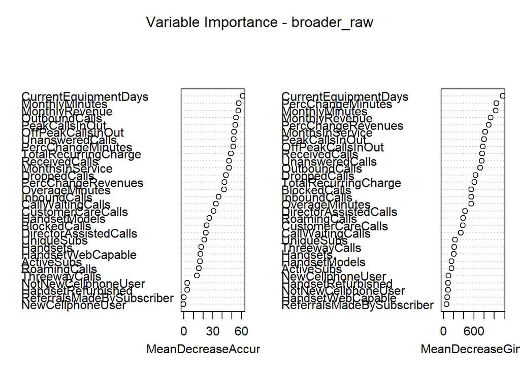

```r
varImpPlot(
  final_forest,
  main = paste("Variable Importance -", selected_model)
)
```

# Estimated Net Revenue

```r
# Fixed outreach capacity
outreach_capacity <- 0.10

# Business assumptions to test
churn_rates <- c(0.15, 0.25, 0.30, 0.40)
retention_success_rates <- c(0.15, 0.25, 0.35, 0.45)
contact_costs <- c(2, 3, 4, 5)

# Retention offer cost
offer_costs <- c(0, 20, 30, 50)

# Revenue projection period. This assumes that the customer will stay for the next 12 months after accepting an offer
projection_months <- 12
```

```r
# Predict churn probabilities on the test set
test_probability <- predict(
  final_forest,
  newdata = final_test[, selected_predictors, drop = FALSE],
  type = "prob"
)[, "1"]

# Observed churn rate in the training dataset
sample_churn_rate <- mean(
  as.numeric(as.character(training$churn_flag))
)

sample_churn_rate
```

```
## [1] 0.2881807
```

Adjusts the model’s predicted churn probabilities to reflect an assumed real-world churn rate.

```r
adjust_probabilities <- function(probability, sample_rate, target_rate) {

  sample_odds <- probability / (1 - probability)

  adjusted_odds <- sample_odds *
    (target_rate / (1 - target_rate)) /
    (sample_rate / (1 - sample_rate))

  adjusted_probability <- adjusted_odds / (1 + adjusted_odds)

  adjusted_probability
}
```

Calculate Net Revenue for each combination of the assumptions.

```r
# Create all combinations of assumptions
scenarios <- expand.grid(
  Churn_Rate = churn_rates,
  Retention_Success_Rate = retention_success_rates,
  Contact_Cost = contact_costs,
  Offer_Cost = offer_costs
)

# Customer monthly revenue
monthly_revenue <- as.numeric(final_test$MonthlyRevenue)

# Number of customers to contact
n_contact <- floor(nrow(final_test) * outreach_capacity)

# Calculate revenue for each scenario
revenue_results_rf <- do.call(
  rbind,
  lapply(seq_len(nrow(scenarios)), function(i) {

    scenario <- scenarios[i, ]

    # Adjust probabilities to the assumed real-world churn rate
    adjusted_probability <- adjust_probabilities(
      probability = test_probability,
      sample_rate = sample_churn_rate,
      target_rate = scenario$Churn_Rate
    )

    # Calculate monthly revenue at risk
    value_at_risk <- adjusted_probability * monthly_revenue

    # Rank customers by revenue at risk
    ranked_customers <- order(
      -value_at_risk,
      final_test$CustomerID
    )

    # Select customers within outreach capacity
    contacted <- head(ranked_customers, n_contact)

    # Expected number of at-risk customers contacted
    expected_at_risk <- sum(
      adjusted_probability[contacted]
    )

    # Expected number of customers retained
    expected_retained <- expected_at_risk *
      scenario$Retention_Success_Rate

    # Expected 12-month revenue saved
    revenue_saved <- sum(
      adjusted_probability[contacted] *
        scenario$Retention_Success_Rate *
        monthly_revenue[contacted] *
        projection_months
    )

    # Total campaign cost
    campaign_cost <- n_contact * (
      scenario$Contact_Cost + scenario$Offer_Cost
    )

    # Net revenue
    net_revenue <- revenue_saved - campaign_cost

    data.frame(
      Churn_Rate = scenario$Churn_Rate,
      Retention_Success_Rate = scenario$Retention_Success_Rate,
      Contact_Cost = scenario$Contact_Cost,
      Offer_Cost = scenario$Offer_Cost,
      Customers_Contacted = n_contact,
      Expected_At_Risk = expected_at_risk,
      Expected_Retained = expected_retained,
      Revenue_Saved = revenue_saved,
      Campaign_Cost = campaign_cost,
      Net_Revenue = net_revenue
    )
  })
)

row.names(revenue_results_rf) <- NULL
```

Similar to the logistic regression, Net Revenue is highest when churn rate and retention success rate is high

```r
revenue_results_rf |>
  arrange(desc(Net_Revenue)) |>
  head(10)
```

```
##    Churn_Rate Retention_Success_Rate Contact_Cost Offer_Cost
## 1         0.4                   0.45            2          0
## 2         0.4                   0.45            3          0
## 3         0.4                   0.45            4          0
## 4         0.4                   0.45            5          0
## 5         0.4                   0.45            2         20
## 6         0.4                   0.45            3         20
## 7         0.4                   0.45            4         20
## 8         0.4                   0.45            5         20
## 9         0.4                   0.45            2         30
## 10        0.4                   0.45            3         30
##    Customers_Contacted Expected_At_Risk Expected_Retained Revenue_Saved
## 1                 1276         610.7782          274.8502      478143.3
## 2                 1276         610.7782          274.8502      478143.3
## 3                 1276         610.7782          274.8502      478143.3
```

[output cut: 18 more lines]

```r
# saves the scenario dataframe as a csv
write.csv(revenue_results_rf, file = "revenue_scenarios/forest_revenue_estimates.csv", row.names = FALSE)
```

```r
best_scenario_rf <- revenue_results_rf[
  which.max(revenue_results_rf$Net_Revenue),
]
print(best_scenario_rf, row.names = FALSE)
```

```
##  Churn_Rate Retention_Success_Rate Contact_Cost Offer_Cost Customers_Contacted
##         0.4                   0.45            2          0                1276
##  Expected_At_Risk Expected_Retained Revenue_Saved Campaign_Cost Net_Revenue
##          610.7782          274.8502      478143.3          2552    475591.3
```

```r
# Average net revenue by assumed churn rate
aggregate(
  Net_Revenue ~ Churn_Rate,
  data = revenue_results_rf,
  FUN = mean
)
```

```
##   Churn_Rate Net_Revenue
## 1       0.15    98521.22
## 2       0.25   175958.51
## 3       0.30   212468.56
## 4       0.40   282396.21
```

```r
# Average net revenue by retention success rate
aggregate(
  Net_Revenue ~ Retention_Success_Rate,
  data = revenue_results_rf,
  FUN = mean
)
```

```
##   Retention_Success_Rate Net_Revenue
## 1                   0.15    77985.06
## 2                   0.25   154219.10
## 3                   0.35   230453.15
## 4                   0.45   306687.19
```

```r
# Average net revenue by contact cost
aggregate(
  Net_Revenue ~ Contact_Cost,
  data = revenue_results_rf,
  FUN = mean
)
```

```
##   Contact_Cost Net_Revenue
## 1            2    194250.1
## 2            3    192974.1
## 3            4    191698.1
## 4            5    190422.1
```

```r
# Average net revenue by offer cost
aggregate(
  Net_Revenue ~ Offer_Cost,
  data = revenue_results_rf,
  FUN = mean
)
```

```
##   Offer_Cost Net_Revenue
## 1          0    224236.1
## 2         20    198716.1
## 3         30    185956.1
## 4         50    160436.1
```

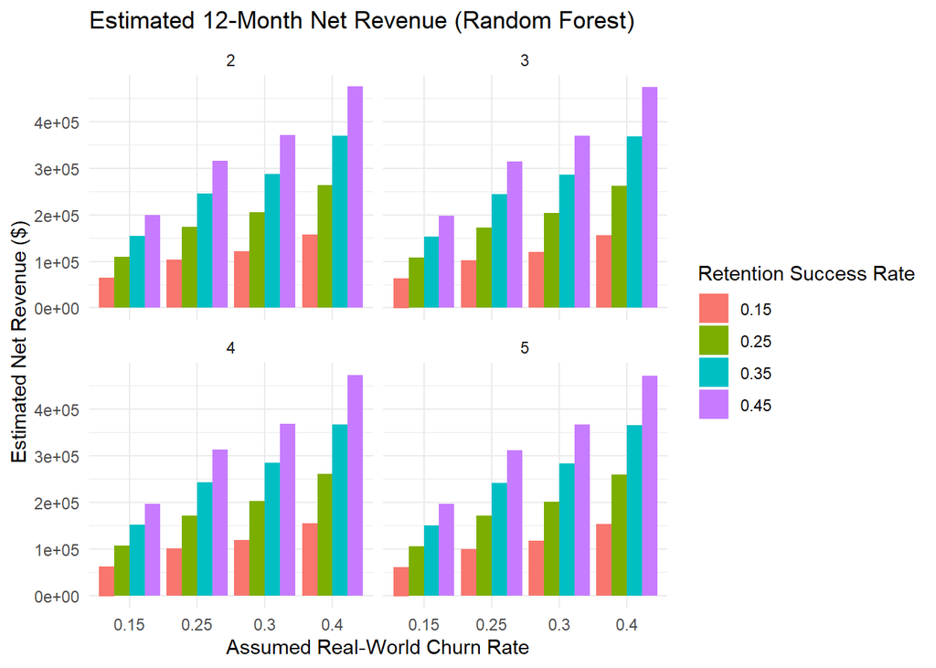

```r
library(ggplot2)

ggplot(
  revenue_results_rf,
  aes(
    x = factor(Churn_Rate),
    y = Net_Revenue,
    fill = factor(Retention_Success_Rate)
  )
) +
  geom_col(position = "dodge") +
  facet_wrap(~ Contact_Cost) +
  labs(
    title = "Estimated 12-Month Net Revenue (Random Forest)",
    x = "Assumed Real-World Churn Rate",
    y = "Estimated Net Revenue ($)",
    fill = "Retention Success Rate"
  ) +
  theme_minimal()
```